# Machine Learning Project

Ann Charlton

Saturday, May 23, 2015

## Building the Model

The first step was to clean the data. 2 types of records appeared in the dataset, and they populated different columns with data. The records with the new_window field equal to “yes” summarized information, but all of the fields used by the 20 test examples were “NA” for these summary records. So I first removed these summary records. I then removed all the columns that had predominantly “NA” values that had been used by the summary records. This left 52 different variables were used along with user_name.

```r
library(caret); library(ggplot2); library(randomForest)
data <- read.csv("http://d396qusza40orc.cloudfront.net/predmachlearn/pml-training.csv",header=TRUE)
data <- subset(data,new_window=="no")
data_clean <- data[,c(2,8:11,37:49,60:68,84:86,102,113:124,140,151:160)]
```

I the split the data into 70% for the training set and 30% for the testing set.

```r
set.seed(111)
inTrain <- createDataPartition(y=data_clean$classe,p=0.7,list=FALSE)
training <- data_clean[inTrain,]
testing <- data_clean[-inTrain,]
```

The model type that created the best fit was a random forest model because of the non-linear nature of the data.

```r
modelFit <- randomForest(classe ~., data=training)
```

## Cross Validation

In order to cross validate, I predicted values using the testing set and the model created in the previous step. 99.48% of the records had correctly predicted classifications in the testing set.

```r
pred <- predict(modelFit, testing)
testing$predRight <- pred==testing$classe
sum(testing$predRight)/length(testing$predRight)
```

```
## [1] 0.9947944
```

## Expected Out of Sample Error

The expected out of sample error rate according to the model was 0.62% and the confusion matrix is shown below:

```r
modelFit
```

```
##
## Call:
##  randomForest(formula = classe ~ ., data = training)
##                Type of random forest: classification
##                      Number of trees: 500
## No. of variables tried at each split: 7
##
##         OOB estimate of  error rate: 0.62%
## Confusion matrix:
##      A    B    C    D    E class.error
## A 3826    3    0    0    1 0.001044386
## B   14 2584    5    0    0 0.007299270
## C    0   18 2325    4    0 0.009373669
## D    1    0   27 2174    1 0.013163867
## E    0    0    3    6 2461 0.003643725
```

## Variables

The most influential variables in predicting classification were roll_belt, yaw_belt, pitch_forearm, and magnet_dumbbell_z. Here are the 10 most important variables:

roll_belt 838.30129 yaw_belt 591.59265 pitch_forearm 531.74118 magnet_dumbbell_z 514.92269 pitch_belt 463.73437 magnet_dumbbell_y 457.68085 roll_forearm 413.27733 magnet_dumbbell_x 324.33617 roll_dumbbell 284.82571 magnet_belt_y 278.94707

A plot of magnet_dumbbell_z with another influential variable, magnet_dumbbell_x, shows the circular nature of the dumbbell motion.

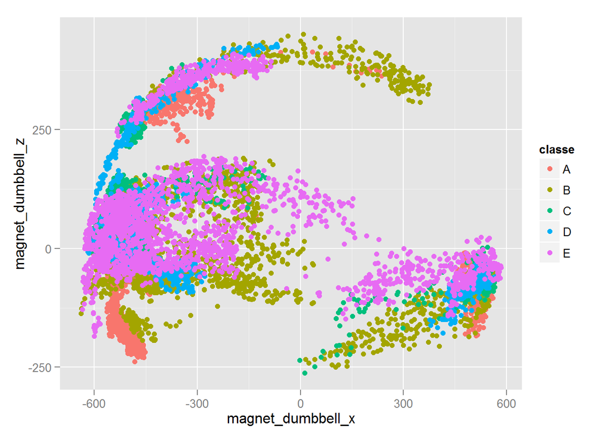

```r
qplot(magnet_dumbbell_x,magnet_dumbbell_z,colour=classe,data=training)
```

## Results

```r
validate <- read.csv("http://d396qusza40orc.cloudfront.net/predmachlearn/pml-testing.csv",header=TRUE)
validate_clean <- validate[,c(2,8:11,37:49,60:68,84:86,102,113:124,140,151:160)]
pred2 <- predict(modelFit, validate_clean)
```